# BrainEnergyOutput

[output not shown]

Log  
Log - Log - October 11, 2019

* Chart Builder.  
GGRAPH  
/GRAPHDATASET NAME="graphdataset" VARIABLES=rCMRGlc slope MISSING=LISTWISE REPORTMISSING=NO  
/GRAPHSPEC SOURCE=INLINE.  
BEGIN GPL  
SOURCE: s=userSource(id("graphdataset"))  
DATA: rCMRGlc=col(source(s), name("rCMRGlc"))  
DATA: slope=col(source(s), name("slope"))  
GUIDE: axis(dim(1), label("rCMRGlc"))  
GUIDE: axis(dim(2), label("slope"))  
ELEMENT: point(position(rCMRGlc*slope))  
END GPL.

GGraph  
GGraph - Graph - October 11, 2019

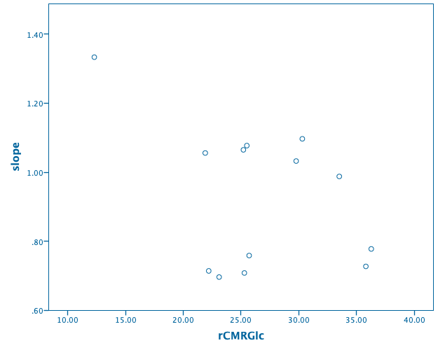

Log  
Log - Log - October 11, 2019

* Chart Builder.  
GGRAPH  
/GRAPHDATASET NAME="graphdataset" VARIABLES=rCMRGlc lambd MISSING=LISTWISE REPORTMISSING=NO  
/GRAPHSPEC SOURCE=INLINE.  
BEGIN GPL  
SOURCE: s=userSource(id("graphdataset"))  
DATA: rCMRGlc=col(source(s), name("rCMRGlc"))  
DATA: lambd=col(source(s), name("lambd"))  
GUIDE: axis(dim(1), label("rCMRGlc"))  
GUIDE: axis(dim(2), label("lambd"))  
ELEMENT: point(position(rCMRGlc*lambd))  
END GPL.

GGraph  
GGraph - Graph - October 11, 2019

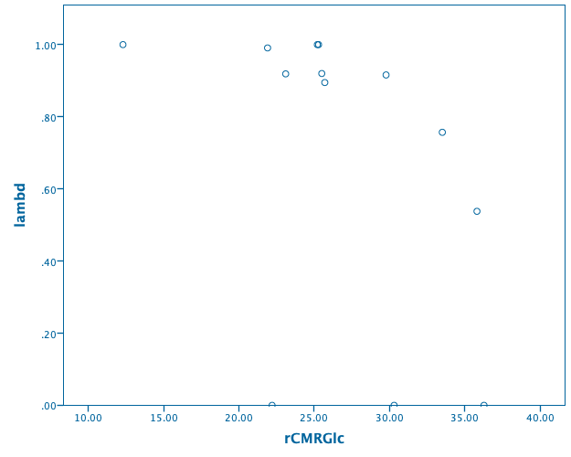

Log  
Log - Log - October 11, 2019

* Chart Builder.  
GGRAPH  
/GRAPHDATASET NAME="graphdataset" VARIABLES=rCMRGlc OPdiff MISSING=LISTWISE REPORTMISSING=NO  
/GRAPHSPEC SOURCE=INLINE.  
BEGIN GPL  
SOURCE: s=userSource(id("graphdataset"))  
DATA: rCMRGlc=col(source(s), name("rCMRGlc"))  
DATA: OPdiff=col(source(s), name("OPdiff"))  
GUIDE: axis(dim(1), label("rCMRGlc"))  
GUIDE: axis(dim(2), label("OPdiff"))  
ELEMENT: point(position(rCMRGlc*OPdiff))  
END GPL.

GGraph  
GGraph - Graph - October 11, 2019

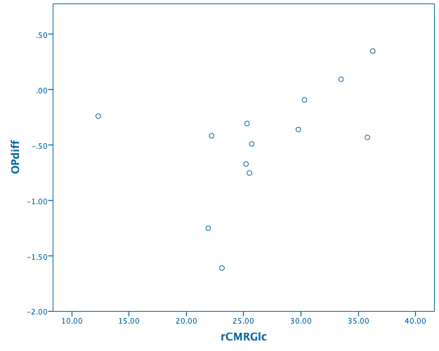

Log  
Log - Log - October 11, 2019

* Chart Builder.  
GGRAPH  
/GRAPHDATASET NAME="graphdataset" VARIABLES=rCMRGlc ageBeta MISSING=LISTWISE REPORTMISSING=NO  
/GRAPHSPEC SOURCE=INLINE.  
BEGIN GPL  
SOURCE: s=userSource(id("graphdataset"))  
DATA: rCMRGlc=col(source(s), name("rCMRGlc"))  
DATA: ageBeta=col(source(s), name("ageBeta"))  
GUIDE: axis(dim(1), label("rCMRGlc"))  
GUIDE: axis(dim(2), label("ageBeta"))  
ELEMENT: point(position(rCMRGlc*ageBeta))  
END GPL.

GGraph  
GGraph - Graph - October 11, 2019

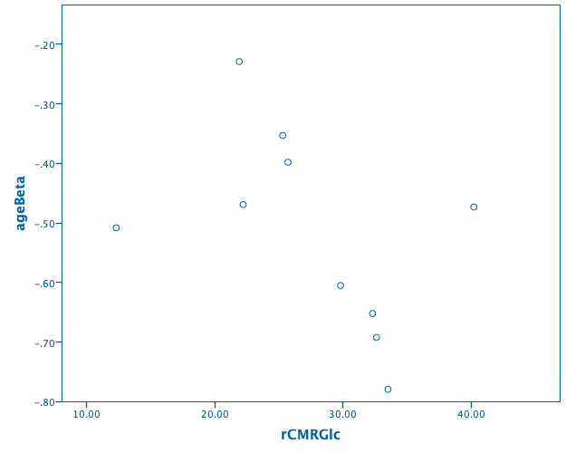

Log  
Log - Log - October 11, 2019

* Chart Builder.  
GGRAPH  
/GRAPHDATASET NAME="graphdataset" VARIABLES=rCMRGlc ageChange MISSING=LISTWISE REPORTMISSING=NO  
/GRAPHSPEC SOURCE=INLINE.  
BEGIN GPL  
SOURCE: s=userSource(id("graphdataset"))  
DATA: rCMRGlc=col(source(s), name("rCMRGlc"))  
DATA: ageChange=col(source(s), name("ageChange"))  
GUIDE: axis(dim(1), label("rCMRGlc"))  
GUIDE: axis(dim(2), label("ageChange"))  
ELEMENT: point(position(rCMRGlc*ageChange))  
END GPL.

GGraph  
GGraph - Graph - October 11, 2019

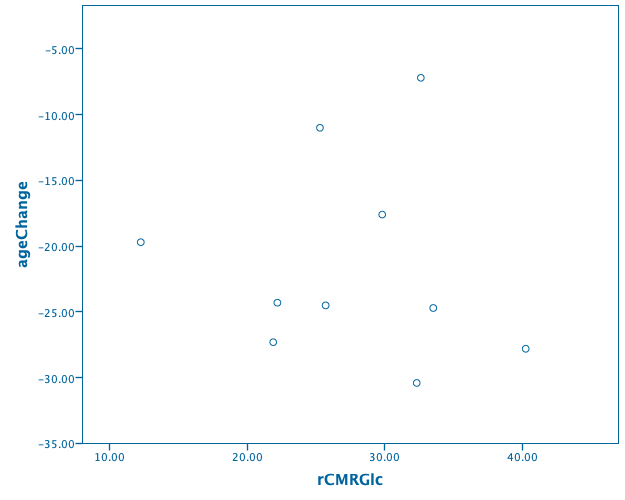

Log  
Log - Log - October 11, 2019

* Chart Builder.  
GGRAPH  
/GRAPHDATASET NAME="graphdataset" VARIABLES=rCMRGlc devChange MISSING=LISTWISE REPORTMISSING=NO  
/GRAPHSPEC SOURCE=INLINE.  
BEGIN GPL  
SOURCE: s=userSource(id("graphdataset"))  
DATA: rCMRGlc=col(source(s), name("rCMRGlc"))  
DATA: devChange=col(source(s), name("devChange"))  
GUIDE: axis(dim(1), label("rCMRGlc"))  
GUIDE: axis(dim(2), label("devChange"))  
ELEMENT: point(position(rCMRGlc*devChange))  
END GPL.

GGraph  
GGraph - Graph - October 11, 2019

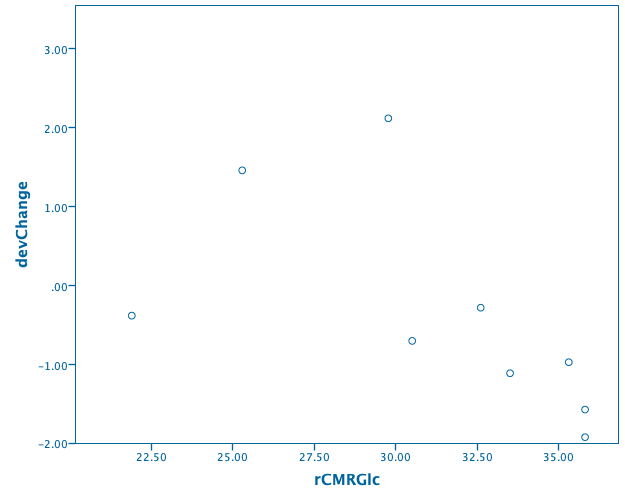

Log  
Log - Log - October 11, 2019

* Log  
* Chart Builder.  
GGRAPH  
/GRAPHDATASET NAME="graphdataset" VARIABLES=logrCMRGlc slope MISSING=LISTWISE REPORTMISSING=NO  
/GRAPHSPEC SOURCE=INLINE.  
BEGIN GPL  
SOURCE: s=userSource(id("graphdataset"))  
DATA: logrCMRGlc=col(source(s), name("logrCMRGlc"))  
DATA: slope=col(source(s), name("slope"))  
GUIDE: axis(dim(1), label("logrCMRGlc"))  
GUIDE: axis(dim(2), label("slope"))  
ELEMENT: point(position(logrCMRGlc*slope))  
END GPL.

GGraph  
GGraph - Graph - October 11, 2019

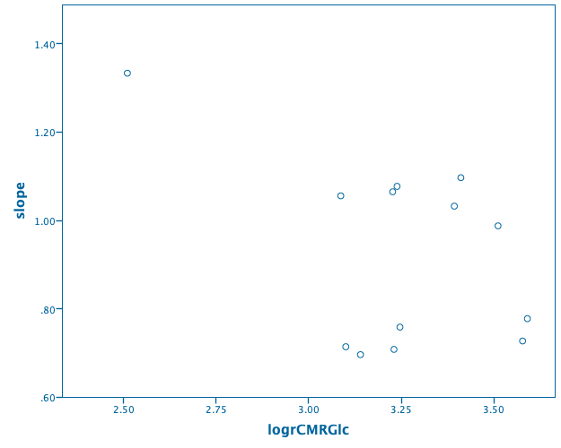

Log  
Log - Log - October 11, 2019

* Chart Builder.  
GGRAPH  
/GRAPHDATASET NAME="graphdataset" VARIABLES=logrCMRGlc lambd MISSING=LISTWISE REPORTMISSING=NO  
/GRAPHSPEC SOURCE=INLINE.  
BEGIN GPL  
SOURCE: s=userSource(id("graphdataset"))  
DATA: logrCMRGlc=col(source(s), name("logrCMRGlc"))  
DATA: lambd=col(source(s), name("lambd"))  
GUIDE: axis(dim(1), label("logrCMRGlc"))  
GUIDE: axis(dim(2), label("lambd"))  
ELEMENT: point(position(logrCMRGlc*lambd))  
END GPL.

GGraph  
GGraph - Graph - October 11, 2019

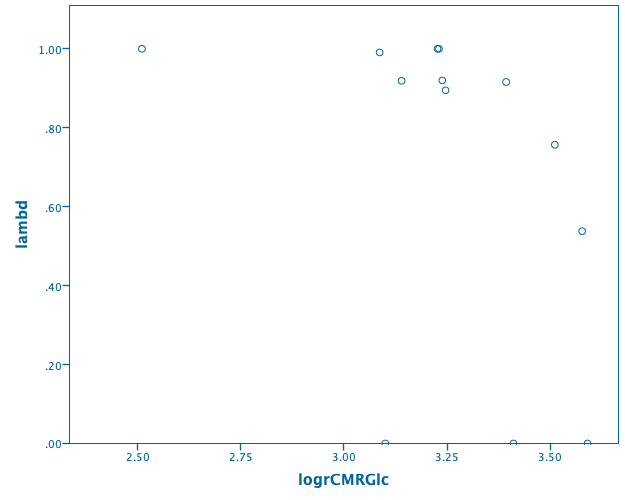

Log  
Log - Log - October 11, 2019

* Chart Builder.  
GGRAPH  
/GRAPHDATASET NAME="graphdataset" VARIABLES=logrCMRGlc OPdiff MISSING=LISTWISE REPORTMISSING=NO  
/GRAPHSPEC SOURCE=INLINE.  
BEGIN GPL  
SOURCE: s=userSource(id("graphdataset"))  
DATA: logrCMRGlc=col(source(s), name("logrCMRGlc"))  
DATA: OPdiff=col(source(s), name("OPdiff"))  
GUIDE: axis(dim(1), label("logrCMRGlc"))  
GUIDE: axis(dim(2), label("OPdiff"))  
ELEMENT: point(position(logrCMRGlc*OPdiff))  
END GPL.

GGraph  
GGraph - Graph - October 11, 2019

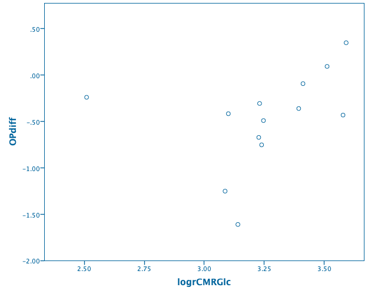

Log  
Log - Log - October 11, 2019

* Chart Builder.  
GGRAPH  
/GRAPHDATASET NAME="graphdataset" VARIABLES=logrCMRGlc ageBeta MISSING=LISTWISE REPORTMISSING=NO  
/GRAPHSPEC SOURCE=INLINE.  
BEGIN GPL  
SOURCE: s=userSource(id("graphdataset"))  
DATA: logrCMRGlc=col(source(s), name("logrCMRGlc"))  
DATA: ageBeta=col(source(s), name("ageBeta"))  
GUIDE: axis(dim(1), label("logrCMRGlc"))  
GUIDE: axis(dim(2), label("ageBeta"))  
ELEMENT: point(position(logrCMRGlc*ageBeta))  
END GPL.

GGraph  
GGraph - Graph - October 11, 2019

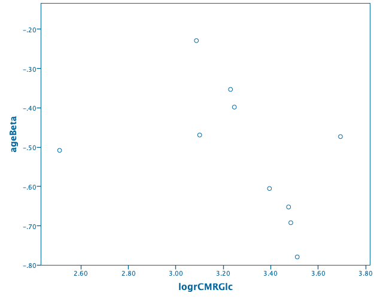

Log  
Log - Log - October 11, 2019

* Chart Builder.  
GGRAPH  
/GRAPHDATASET NAME="graphdataset" VARIABLES=logrCMRGlc ageChange MISSING=LISTWISE REPORTMISSING=NO  
/GRAPHSPEC SOURCE=INLINE.  
BEGIN GPL  
SOURCE: s=userSource(id("graphdataset"))  
DATA: logrCMRGlc=col(source(s), name("logrCMRGlc"))  
DATA: ageChange=col(source(s), name("ageChange"))  
GUIDE: axis(dim(1), label("logrCMRGlc"))  
GUIDE: axis(dim(2), label("ageChange"))  
ELEMENT: point(position(logrCMRGlc*ageChange))  
END GPL.

GGraph  
GGraph - Graph - October 11, 2019

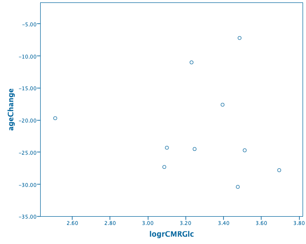

Log  
Log - Log - October 11, 2019

* Chart Builder.  
GGRAPH  
/GRAPHDATASET NAME="graphdataset" VARIABLES=logrCMRGlc devChange MISSING=LISTWISE REPORTMISSING=NO  
/GRAPHSPEC SOURCE=INLINE.  
BEGIN GPL  
SOURCE: s=userSource(id("graphdataset"))  
DATA: logrCMRGlc=col(source(s), name("logrCMRGlc"))  
DATA: devChange=col(source(s), name("devChange"))  
GUIDE: axis(dim(1), label("logrCMRGlc"))  
GUIDE: axis(dim(2), label("devChange"))  
ELEMENT: point(position(logrCMRGlc*devChange))  
END GPL.

GGraph  
GGraph - Graph - October 11, 2019

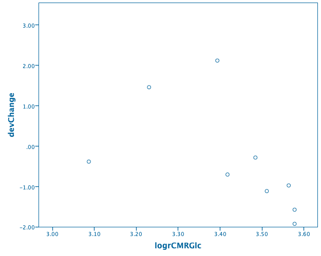

Log  
Log - Log - October 11, 2019

SAVE OUTFILE='/Users/alexandradesousa/Desktop/BrainEnergyData.sav'  
/COMPRESSED.

[output not shown]

[output not shown]

[output not shown]

[output not shown]

[output not shown]

[output not shown]

[output not shown]

[output not shown]

[output not shown]